# Sales Data Visualization - Version 1

## Summary related to Quartly Sales

- Quartly Sales Data Overview
- Quartly Sales Data By Region by Year

### Quartly Sales Data by year

- Data Sum (Create Data Frame for the visualization)
- Data Visualization
  - General Visualization of Quartly Sales Data for each year
  - Compare the Quartly Sales within each year

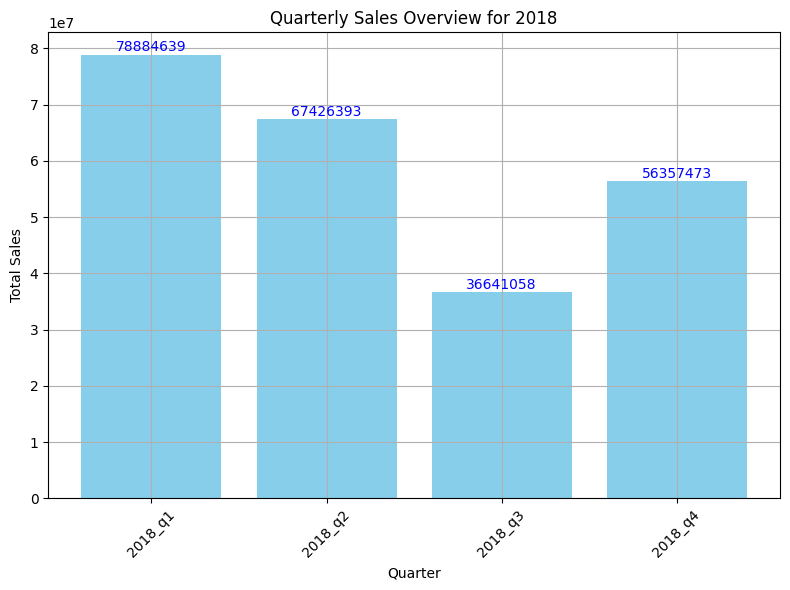

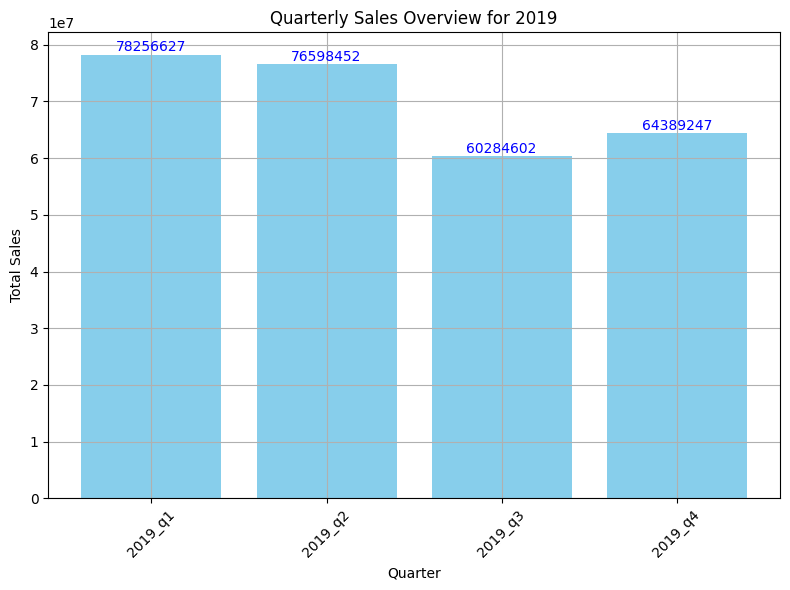

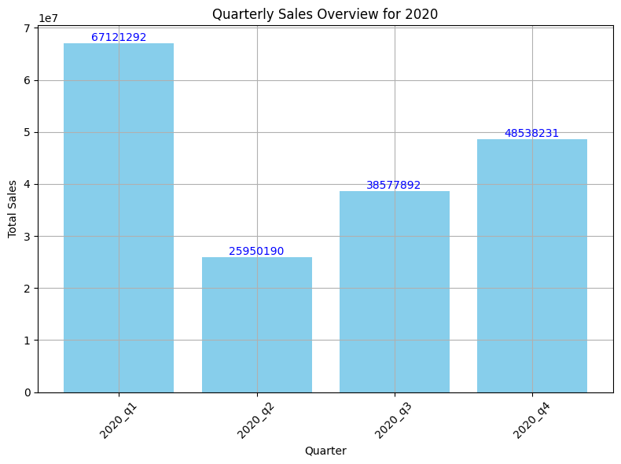

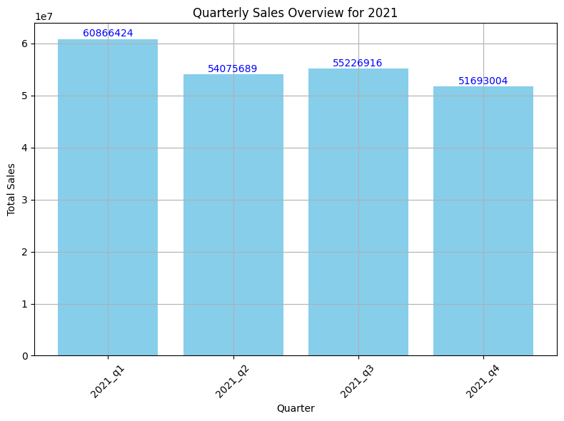

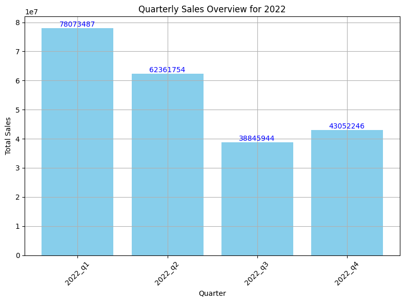

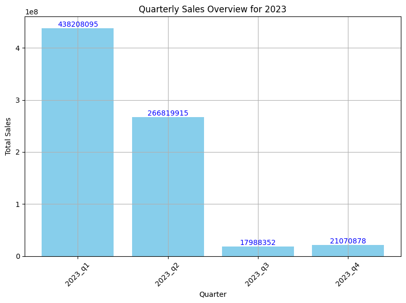

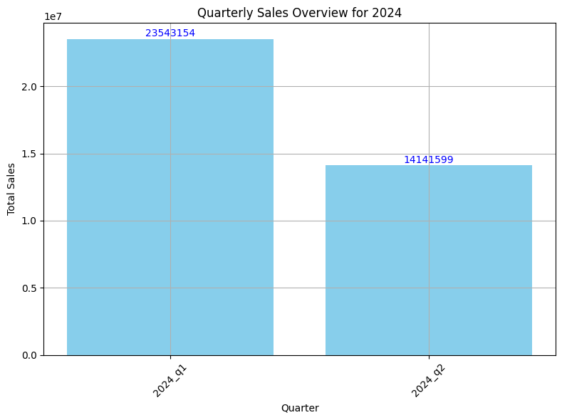

```python
# Create a Quartly Graph for each year

quarterly_sales_columns = {
    '2018': ['2018_q1', '2018_q2', '2018_q3', '2018_q4'],
    '2019': ['2019_q1', '2019_q2', '2019_q3', '2019_q4'],
    '2020': ['2020_q1', '2020_q2', '2020_q3', '2020_q4'],
    '2021': ['2021_q1', '2021_q2', '2021_q3', '2021_q4'],
    '2022': ['2022_q1', '2022_q2', '2022_q3', '2022_q4'],
    '2023': ['2023_q1', '2023_q2', '2023_q3', '2023_q4'],
    '2024': ['2024_q1', '2024_q2']  # Adjust if you only have Q1 and Q2 for 2024
}

# Loop through each year and plot the quarterly sales
for year, quarters in quarterly_sales_columns.items():
    if all(col in merged_df.columns for col in quarters):
        quarterly_sales = merged_df[quarters].sum()

        plt.figure(figsize=(8, 6))
        bars = plt.bar(quarters, quarterly_sales, color='skyblue')
        plt.title(f'Quarterly Sales Overview for {year}')
        plt.xlabel('Quarter')
        plt.ylabel('Total Sales')
        plt.xticks(rotation=45)
        plt.grid(True)

        for bar, sales_value in zip(bars, quarterly_sales):
            plt.text(bar.get_x() + bar.get_width() / 2, bar.get_height() + 5000,
                f'{sales_value:.0f}', ha='center', va='bottom', color='blue')

        plt.tight_layout()
        plt.show()
```

```python
import numpy as np
```

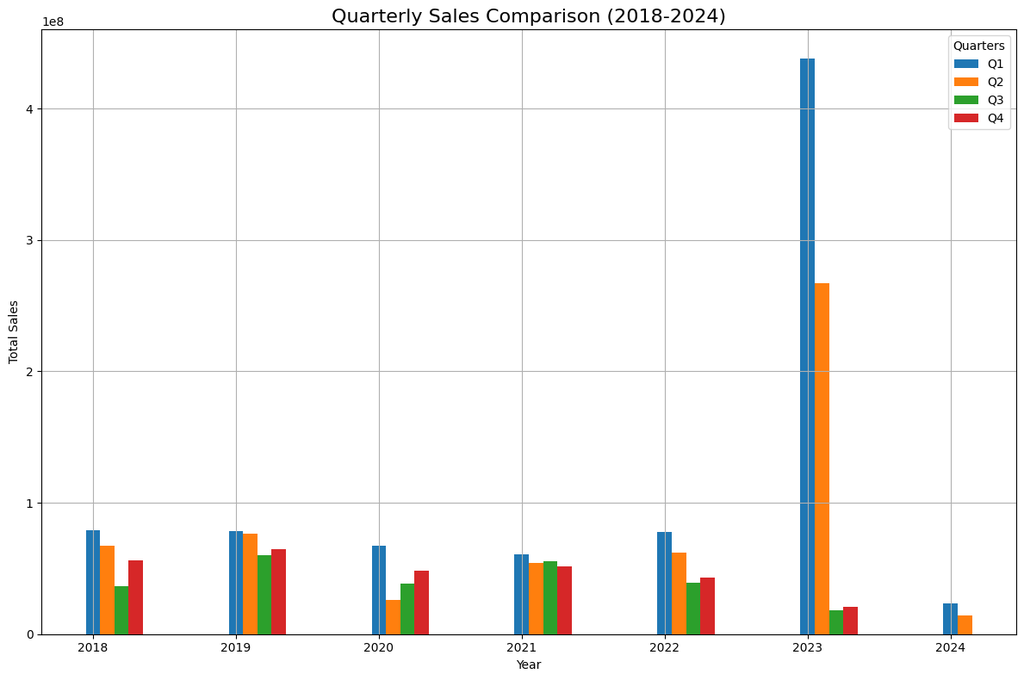

```python
# Quartly Sales Data compare across years
quarterly_sales_columns = {
    'Q1': ['2018_q1', '2019_q1', '2020_q1', '2021_q1', '2022_q1', '2023_q1', '2024_q1'],
    'Q2': ['2018_q2', '2019_q2', '2020_q2', '2021_q2', '2022_q2', '2023_q2', '2024_q2'],
    'Q3': ['2018_q3', '2019_q3', '2020_q3', '2021_q3', '2022_q3', '2023_q3'],
    'Q4': ['2018_q4', '2019_q4', '2020_q4', '2021_q4', '2022_q4', '2023_q4']
}

#Years for the x-axis labels
years = ['2018', '2019', '2020', '2021', '2022', '2023', '2024']
quarters = ['Q1', 'Q2', 'Q3', 'Q4']
width = 0.1

plt.figure(figsize=(12, 8))

for idx, quarter in enumerate(quarters):
    if quarter in quarterly_sales_columns:
        sales_data = [merged_df[col].sum() if col in merged_df.columns else 0 for col in quarterly_sales_columns[quarter]]

        x = np.arange(len(years[:len(sales_data)])) + idx * width

        plt.bar(x, sales_data, width=width, label=quarter)


plt.title('Quarterly Sales Comparison (2018-2024)', fontsize=16)
plt.xlabel('Year')
plt.ylabel('Total Sales')
plt.xticks(np.arange(len(years)), years)
plt.legend(title='Quarters')
plt.grid(True)


plt.tight_layout()
plt.show()
```

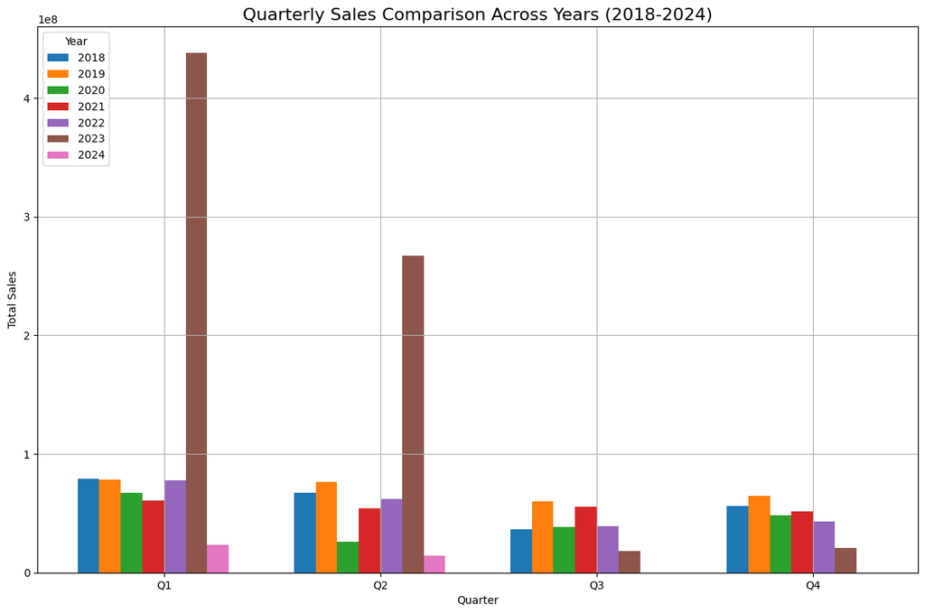

```python
# Direct comparison of each year's quartly sales data
quarterly_sales_columns = {
    'Q1': ['2018_q1', '2019_q1', '2020_q1', '2021_q1', '2022_q1', '2023_q1', '2024_q1'],
    'Q2': ['2018_q2', '2019_q2', '2020_q2', '2021_q2', '2022_q2', '2023_q2', '2024_q2'],
    'Q3': ['2018_q3', '2019_q3', '2020_q3', '2021_q3', '2022_q3', '2023_q3'],
    'Q4': ['2018_q4', '2019_q4', '2020_q4', '2021_q4', '2022_q4', '2023_q4']
}


years = ['2018', '2019', '2020', '2021', '2022', '2023', '2024']
quarters = ['Q1', 'Q2', 'Q3', 'Q4']
x = np.arange(len(quarters))
width = 0.1

plt.figure(figsize=(12, 8))

for i, year in enumerate(years):
    sales_data = []
    for quarter in quarterly_sales_columns:
        column_name = f'{year.lower()}_{quarter.lower()}'
        if column_name in merged_df.columns:
            sales_data.append(merged_df[column_name].sum())
        else:
            sales_data.append(0)

    x_positions = x + i * width

    plt.bar(x_positions, sales_data, width=width, label=year)


plt.title('Quarterly Sales Comparison Across Years (2018-2024)', fontsize=16)
plt.xlabel('Quarter')
plt.ylabel('Total Sales')
plt.xticks(x + width * (len(years) / 2), quarters)
plt.legend(title='Year', loc='upper left')
plt.grid(True)


plt.tight_layout()
plt.show()
```

### Quartly Sales Data by region by year

- Data Sum (Create Data Frame for the visualization)
- Data Visualization

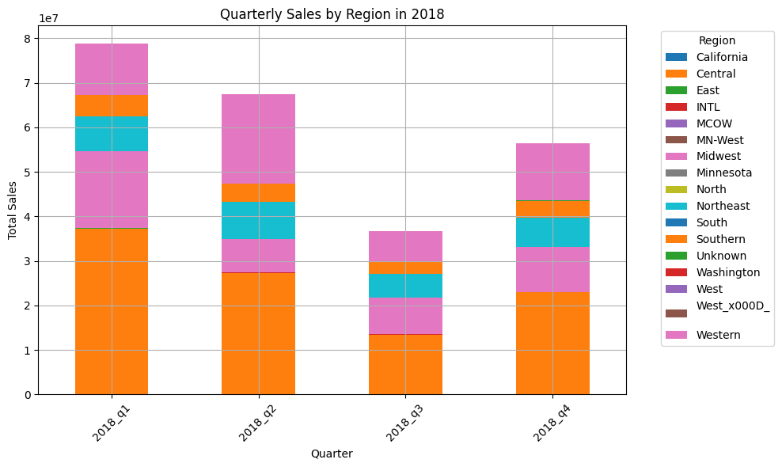

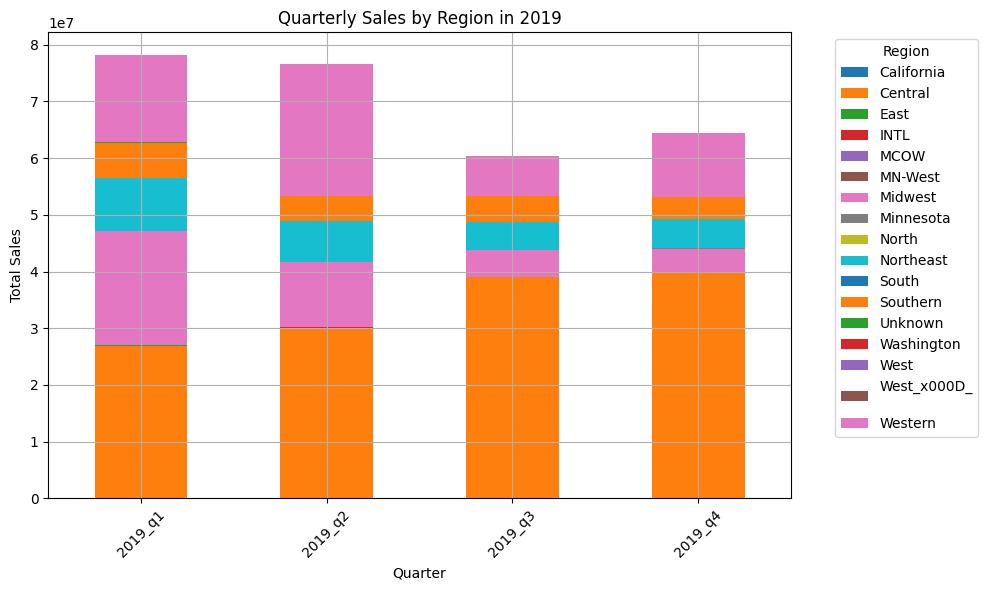

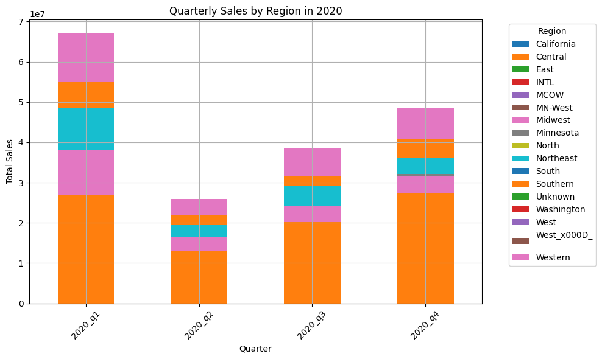

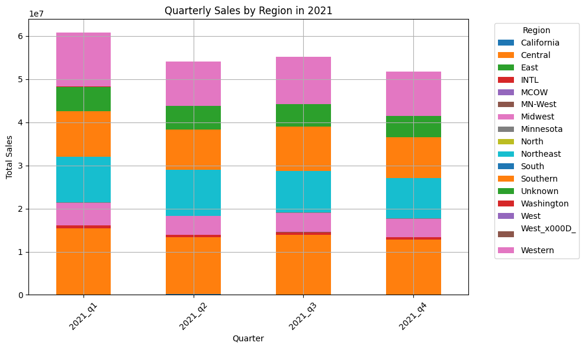

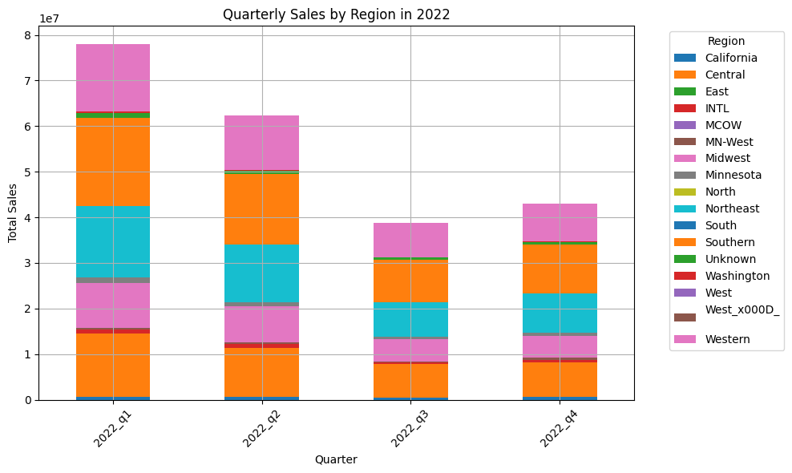

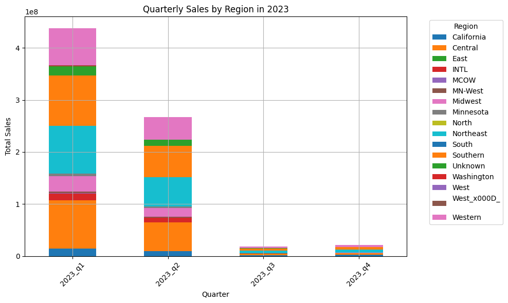

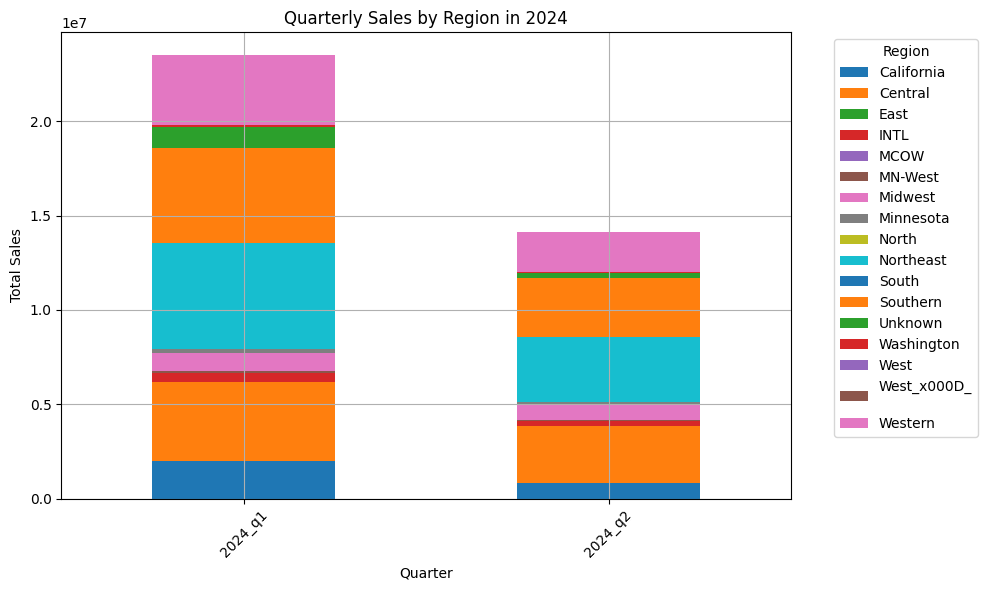

```python
#Check the resions that contribute to quarterly sales data for each year

quarterly_sales_columns = {
    '2018': ['2018_q1', '2018_q2', '2018_q3', '2018_q4'],
    '2019': ['2019_q1', '2019_q2', '2019_q3', '2019_q4'],
    '2020': ['2020_q1', '2020_q2', '2020_q3', '2020_q4'],
    '2021': ['2021_q1', '2021_q2', '2021_q3', '2021_q4'],
    '2022': ['2022_q1', '2022_q2', '2022_q3', '2022_q4'],
    '2023': ['2023_q1', '2023_q2', '2023_q3', '2023_q4'],
    '2024': ['2024_q1', '2024_q2']
}

for year, quarters in quarterly_sales_columns.items():
    if all(col in merged_df.columns for col in quarters):
        region_quarterly_sales = merged_df.groupby('Comp Terr')[quarters].sum()

        plt.figure(figsize=(10, 6))

        region_quarterly_sales.T.plot(kind='bar', stacked=True, figsize=(10, 6), ax=plt.gca())

        plt.title(f'Quarterly Sales by Region in {year}')
        plt.xlabel('Quarter')
        plt.ylabel('Total Sales')
        plt.xticks(rotation=45)
        plt.legend(title='Region', bbox_to_anchor=(1.05, 1), loc='upper left')
        plt.grid(True)

        plt.tight_layout()
        plt.show()
```

## Summary Related to Monthly Sales

- Monthly Sales Data Overview
- Monthly Sales Data by Region by Year

### Monthly Sales Data By Year including the regional contribution

- Data Visualization

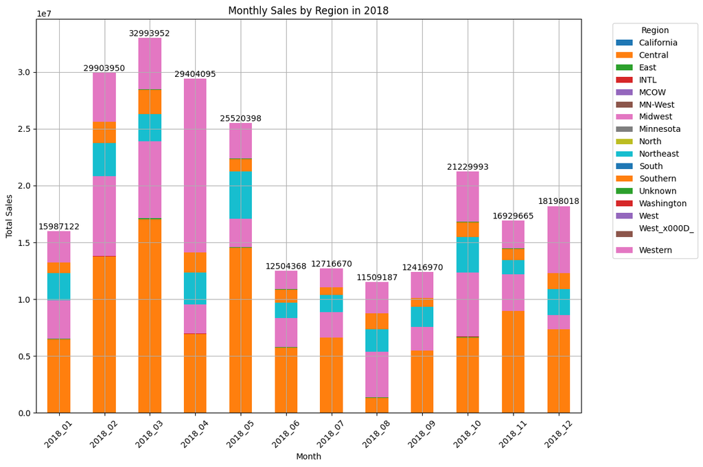

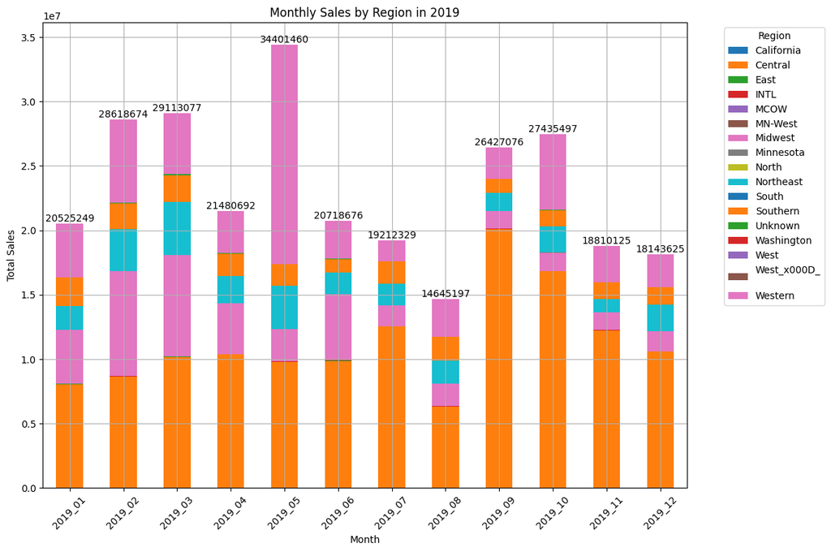

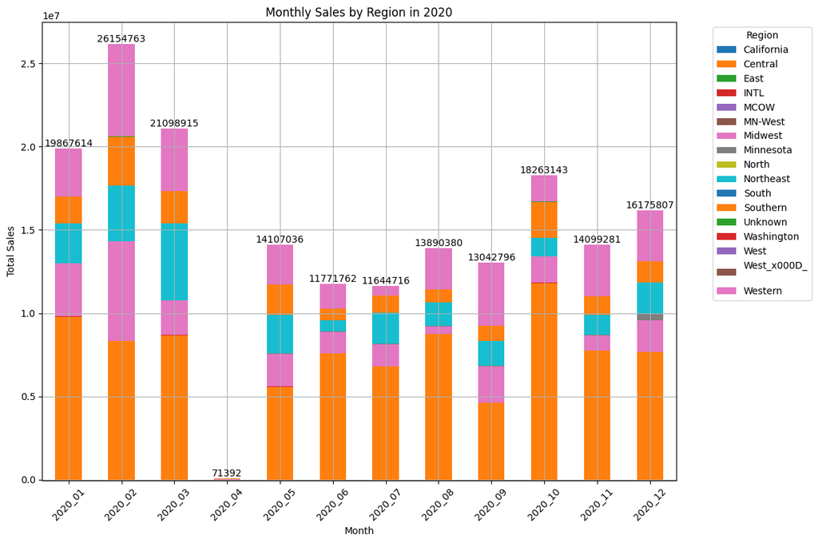

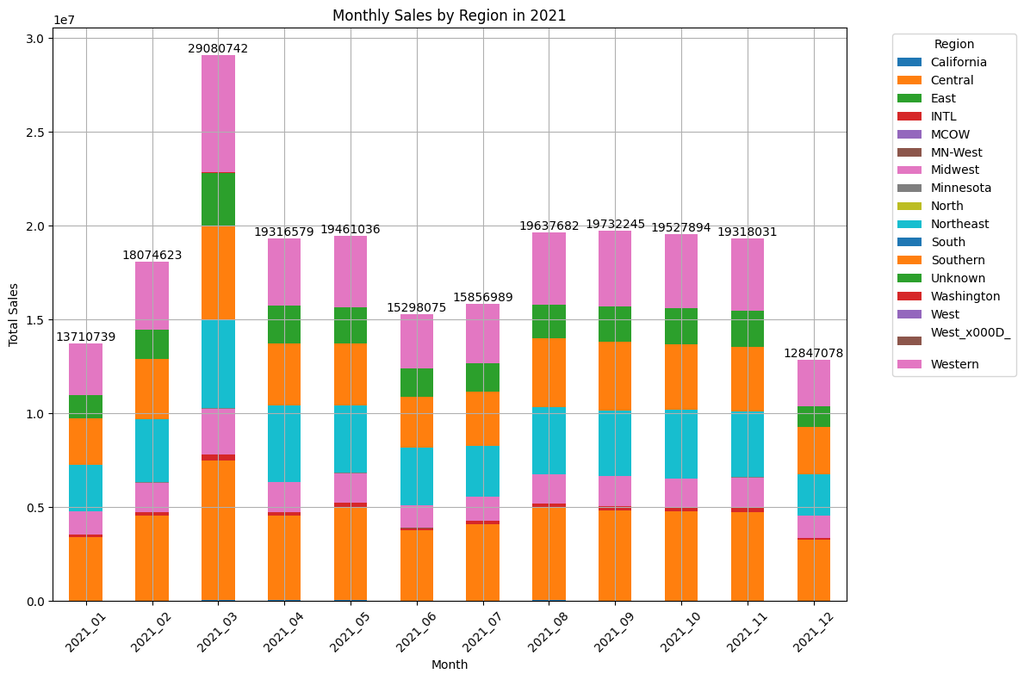

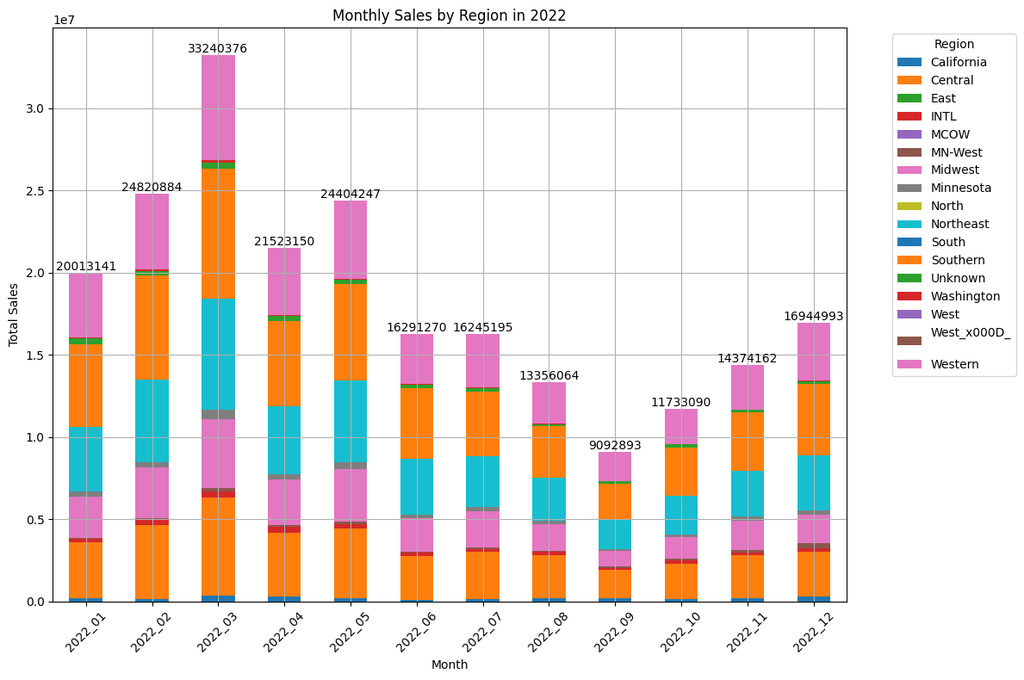

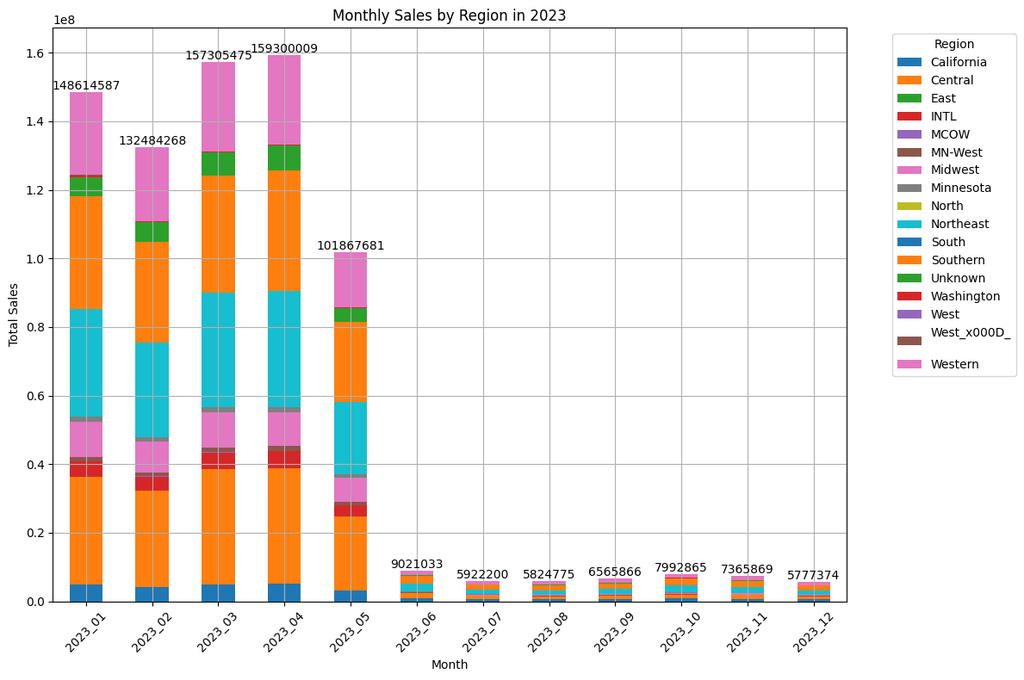

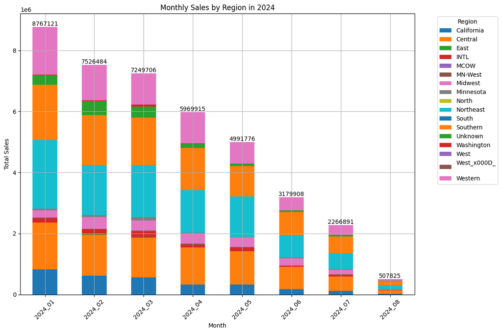

```python
# Monthly Sales Data by year, whith the regional sales contribution to each month's sales

#Define the monthly sales columns for each year
monthly_sales_columns = {
    '2018': [f'2018_{str(month).zfill(2)}' for month in range(1, 13)],
    '2019': [f'2019_{str(month).zfill(2)}' for month in range(1, 13)],
    '2020': [f'2020_{str(month).zfill(2)}' for month in range(1, 13)],
    '2021': [f'2021_{str(month).zfill(2)}' for month in range(1, 13)],
    '2022': [f'2022_{str(month).zfill(2)}' for month in range(1, 13)],
    '2023': [f'2023_{str(month).zfill(2)}' for month in range(1, 13)],
    '2024': [f'2024_{str(month).zfill(2)}' for month in range(1, 9)]
}


for year, months in monthly_sales_columns.items():
    if all(col in merged_df.columns for col in months):
        region_monthly_sales = merged_df.groupby('Comp Terr')[months].sum()


        plt.figure(figsize=(12, 8))
        bars = region_monthly_sales.T.plot(kind='bar', stacked=True, figsize=(12, 8), ax=plt.gca())

        total_monthly_sales = region_monthly_sales.sum(axis=0)

        for idx, sales_value in enumerate(total_monthly_sales):
            plt.text(idx, sales_value + 1000,
                     f'{sales_value:.0f}', ha='center', va='bottom', color='black')

        plt.title(f'Monthly Sales by Region in {year}')
        plt.xlabel('Month')
        plt.ylabel('Total Sales')
        plt.xticks(rotation=45)
        plt.legend(title='Region', bbox_to_anchor=(1.05, 1), loc='upper left')
        plt.grid(True)


        plt.tight_layout()
        plt.show()
```

## Client Related Data Summarization

- Number of Clients with Sales Records (by Year)
- Average Annual Sales by Cliet Numbers (by Year)
- Most Sales amount by one client per year

### Create Graph to show number of accounts with sales record for each year

- summarize the annual number of clients with sales
- create visual representations of the number

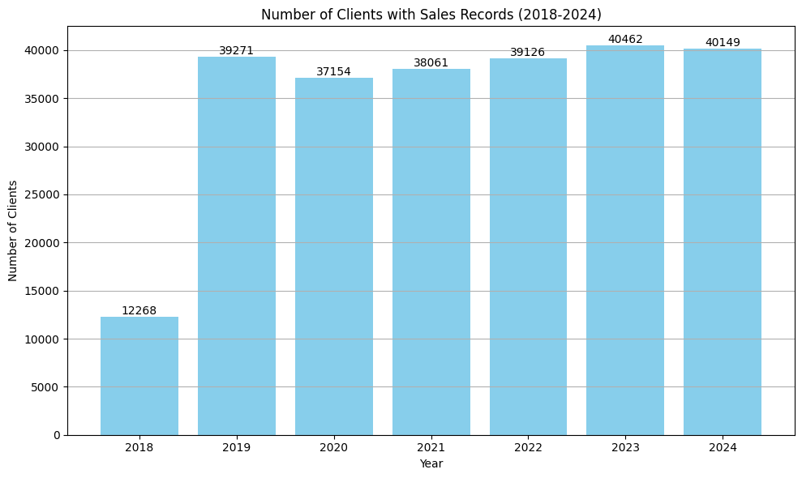

```python
annual_sales_columns = {
    '2018': '2018_sales',
    '2019': '2019_sales',
    '2020': '2020_sales',
    '2021': '2021_sales',
    '2022': '2022_sales',
    '2023': '2023_sales',
    '2024': '2024_sales'
}

clients_with_sales = []


for year, sales_column in annual_sales_columns.items():
    if sales_column in merged_df.columns:
        non_zero_sales_count = merged_df[merged_df[sales_column] > 0]['composite_key'].nunique()
        clients_with_sales.append(non_zero_sales_count)
    else:
        clients_with_sales.append(0)

years = list(annual_sales_columns.keys())

plt.figure(figsize=(10, 6))
bars = plt.bar(years, clients_with_sales, color='skyblue')

for bar, count in zip(bars, clients_with_sales):
    plt.text(bar.get_x() + bar.get_width() / 2, bar.get_height() + 0.5,
             f'{count}', ha='center', va='bottom', color='black')


plt.title('Number of Clients with Sales Records (2018-2024)')
plt.xlabel('Year')
plt.ylabel('Number of Clients')
plt.grid(axis='y')

plt.tight_layout()
plt.show()
```

### Create a graph to show the Average Annual Sales by Number of CLients with Sales

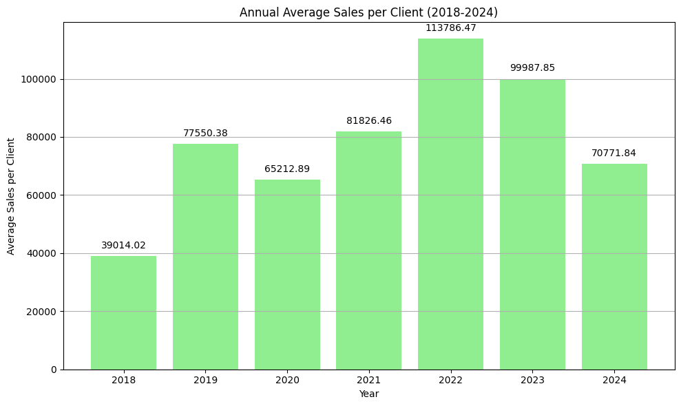

```python
annual_sales_columns = {
    '2018': '2018_sales',
    '2019': '2019_sales',
    '2020': '2020_sales',
    '2021': '2021_sales',
    '2022': '2022_sales',
    '2023': '2023_sales',
    '2024': '2024_sales'
}

total_sales_per_year = []
clients_with_sales_per_year = []
average_sales_per_client = []

for year, sales_column in annual_sales_columns.items():
    if sales_column in merged_df.columns:
        total_sales = merged_df[sales_column].sum()
        total_sales_per_year.append(total_sales)

        non_zero_sales_count = merged_df[merged_df[sales_column] > 0]['composite_key'].nunique()
        clients_with_sales_per_year.append(non_zero_sales_count)

        if non_zero_sales_count > 0:
            average_sales = total_sales / non_zero_sales_count
        else:
            average_sales = 0
        average_sales_per_client.append(average_sales)
    else:
        total_sales_per_year.append(0)
        clients_with_sales_per_year.append(0)
        average_sales_per_client.append(0)

years = list(annual_sales_columns.keys())

plt.figure(figsize=(10, 6))
bars = plt.bar(years, average_sales_per_client, color='lightgreen')

for bar, avg_sales in zip(bars, average_sales_per_client):
    plt.text(bar.get_x() + bar.get_width() / 2, bar.get_height() + 2000,
             f'{avg_sales:.2f}', ha='center', va='bottom', color='black')

plt.title('Annual Average Sales per Client (2018-2024)')
plt.xlabel('Year')
plt.ylabel('Average Sales per Client')
plt.grid(axis='y')


plt.tight_layout()
plt.show()
```

### Create a dashboard to show the top 10 clients (by composit_key) with the highest sales number

```python
annual_sales_columns = {
    '2018': '2018_sales',
    '2019': '2019_sales',
    '2020': '2020_sales',
    '2021': '2021_sales',
    '2022': '2022_sales',
    '2023': '2023_sales',
    '2024': '2024_sales'
}

top_clients = {}

for year, sales_column in annual_sales_columns.items():
    if sales_column in merged_df.columns:
        top_10_clients = merged_df[['composite_key', sales_column]].sort_values(by=sales_column, ascending=False).head(10)
        top_clients[year] = top_10_clients['composite_key'].values

top_clients_df = pd.DataFrame(top_clients, index=[f'Client {i+1}' for i in range(10)])

print("Top 10 Clients by Composite Key for Each Year")
print(top_clients_df)
```

```
Top 10 Clients by Composite Key for Each Year
                                           2018  \
Client 1   C4012242561#>M*UTOli-OOR80Q0#YC<*CB\
Client 2   C3012483637#>M*UTMol-NYUSXFP)RY3@CB\
Client 3   C3111559900#>M*UTGer-OJWUAZT(GWQL^EO
Client 4   C2091341162#>M*UTGil-NPBCQHM+X6;HCB\
Client 5   C0020441081%#J(2CJoe-LTAWCY1&N+[3<E,
Client 6   C1092360274#>M*UTAlv-MZYUUJ7#EEJ<@*D
Client 7   C2041339960#>M*UTAbi-NEDSS4V!U!9YCB\
Client 8   C4072654330&5#9KCSus-P21UZUE&;LL ;!2
Client 9   C0030260017#>M*UTAng-LV8WNI4&1(+SCS#
Client 10  C2111568450#>M*UTAnn-NTUB66F NZU2!U`

                                           2019  \
Client 1   C0111337038%X8K;QReb-MDINQAT(K(W&<E,
Client 2   A4080455016#>M*UTJay-AKSG6BH$V0&Q&`6
Client 3   A7111343660#F@<ZQRic-CY8CLS4)W%HWQ(?
Client 4   A7111344067$5WW;QRit-CY8D1GL)6P^WQ(?
Client 5   A4042932807(V#`$TJen-ADUAW69#$@A?,<!
Client 6   B5010540233#>M*UTSar-I4P7LJS%Q92*EVU
Client 7   B7071958052(!WQS7Mik-JYVBKT0%YN5C75\
Client 8   B4091849587!Z`I[<Phi-HWX167H%8%#ZEVU
Client 9   A4080455131#>M*UTEri-AKSGAS8(]T{#&`6
Client 10  A9032346818%<B!O&Bro-DXO2221(DZ$>&K0

                                           2020  \
Client 1   C0030227763)K=)$QCry-LV7Y34Z$(B9LQ(?
Client 2   C0030227822$(B9LQCus-LV7Y5EM(3#D&Q(?
Client 3   B2032755413)\&F53Ind-G49J4AU(]/!@3{G
Client 4   B0012043347)XJ^0&Kel-EJBDR17))B?A&`6
Client 5   B2032650627$ =IG,Whi-G46TECH!.6[K,C-
Client 6   B2032650542%M+R(,Jam-G46TB1H(Q[Q{,C-
Client 7   B2032650338$YZ_],Kar-G46T373#A%$F,C-
Client 8   B2032347505&^Z[*TVan-G3Z09WK(YC;{9{H
Client 9   B2032336452$T2^_&Ann-G3YOFG7 X.56&K0
Client 10  B2032145972*SZ=FTJos-G3TTG2V)8$ ?7_*

                                           2021  \
Client 1   B8121749388!{LD>TCry-KZQBXFH#]W<_7.1
Client 2   A8112129862)FQ^*^Pro-DOXVG3V(Y$V#^O=
```

[output cut: 29 more lines]

```
Client 8   A7052241236%UN-^3Sha-CLQ2G05)X=L`3{G
Client 9   B0101432827$A.K#&Dar-F2DOU9H$B0SGN+(
Client 10  B9051630440!#PX=&Cin-LAFGNI6&@H>`&`6

                                           2024
Client 1   B0070955414&Z+LZXAwa-EVGVKD6%U 1KXG,
Client 2   B7091952396!0NQTU9A8-K3AM98R!XN>HU)M
Client 3   A7052237326#/-=F3Kar-CLPY96H(Q_$+3{G
Client 4   A7052237326!53#73Lau-CLPY967%UT{73{G
Client 5   A7052237326!:\@D3Dea-CLPY96V(>I!K3{G
Client 6   B7091952396&BG4PUF55-K3AM99D*>.6\U)M
Client 7   B7091952396&&OHOU76A-K3AM992&/^T:U)M
Client 8   B7091952396#N@HOUEDA-K3AM98H(*O>!U)M
Client 9   B7091952396 FR0WU314-K3AM98B(({*SU)M
Client 10  B7091952395#Y`$*U02C-K3AM97J$GAG+U)M
```

```python
output_filename = "top_10_clients_by_year.xlsx"
top_clients_df.to_excel(output_filename, sheet_name='Top 10 Clients')

print(f"Matrix exported to {output_filename}")
```

```
Matrix exported to top_10_clients_by_year.xlsx
```